# Regresión lineal

Hemos reducido el modelo a las variables que tienen relación significativa con la variable de salida en el contexto de una regresión lineal múltiple, partiendo de un escenario con todas las variables explicativas posibles.

- ¿Cómo varía la respuesta frente a cada uno de los predictores?

La variable `mpg` decrece con `weight` y crece con `year`.

- ¿Parecen existir problemas en el ajuste del modelo?

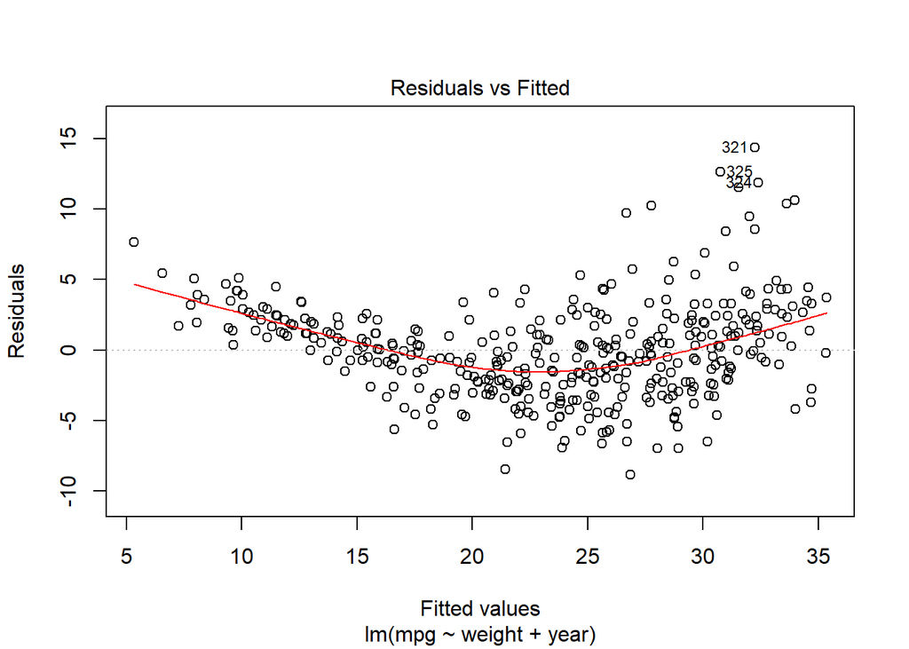

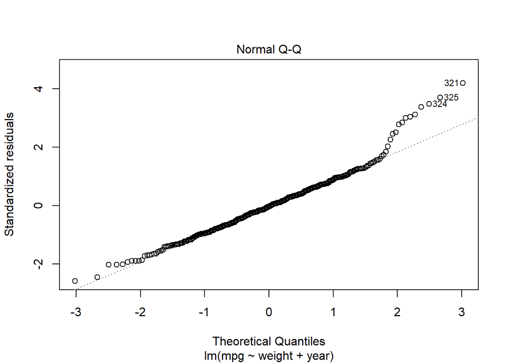

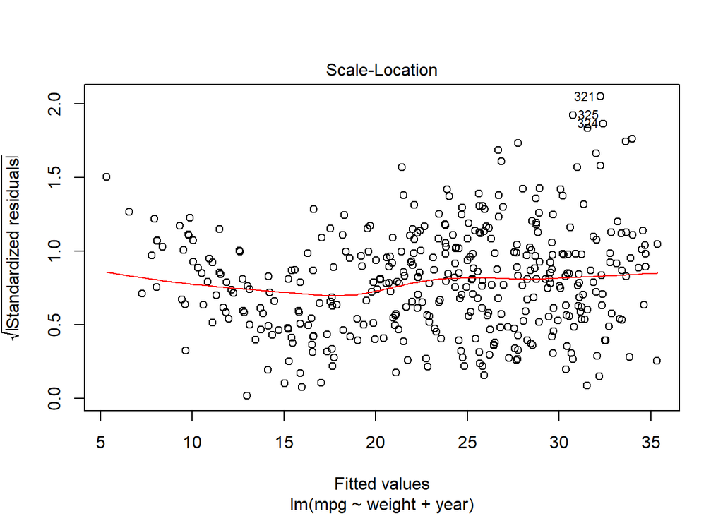

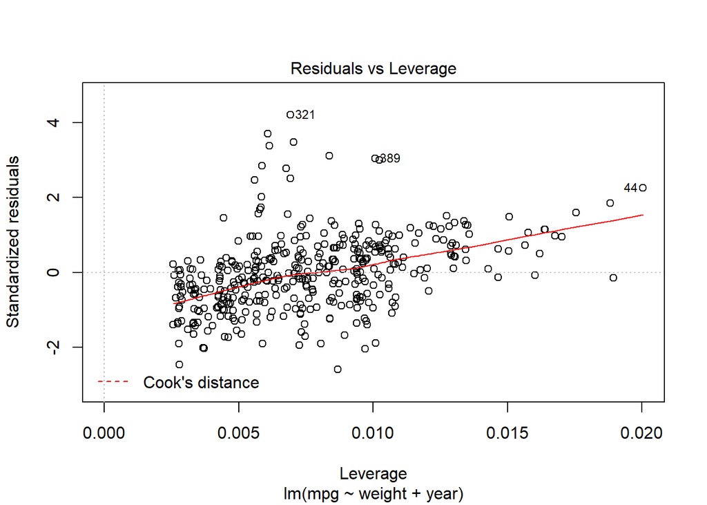

```r
plot(lm.fit.Auto.wy)
```

Los residuos no se comportan como debieran, no tienen media cero, ni varianza constante.

Probemos alguna transformación sobre las variables de entrada. Por ejemplo:

```r
lm.fit.Auto.1_wy <- lm(mpg ~ I(1/weight) + year, Auto)

summary(lm.fit.Auto.1_wy)
```

```
##
## Call:
## lm(formula = mpg ~ I(1/weight) + year, data = Auto)
##
## Residuals:
##    Min     1Q Median     3Q    Max
## -9.242 -1.755 -0.151  1.563 13.426
##
## Coefficients:
##               Estimate Std. Error t value Pr(>|t|)
## (Intercept) -6.005e+01  3.210e+00  -18.71   <2e-16 ***
## I(1/weight)  5.802e+04  1.612e+03   35.99   <2e-16 ***
## year         8.216e-01  4.354e-02   18.87   <2e-16 ***
## ---
## Signif. codes:  0 '***' 0.001 '**' 0.01 '*' 0.05 '.' 0.1 ' ' 1
##
## Residual standard error: 3.062 on 389 degrees of freedom
## Multiple R-squared:  0.8469, Adjusted R-squared:  0.8461
## F-statistic:  1076 on 2 and 389 DF,  p-value: < 2.2e-16
```

Ahora el $R^2$ es mejor que antes.

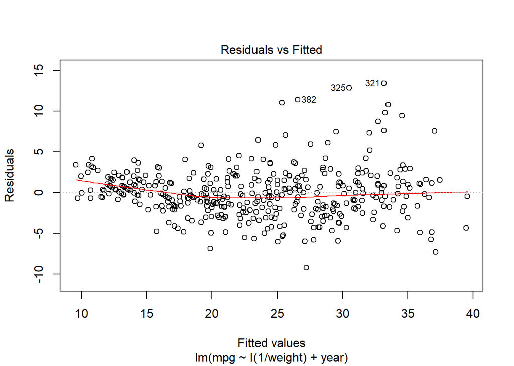

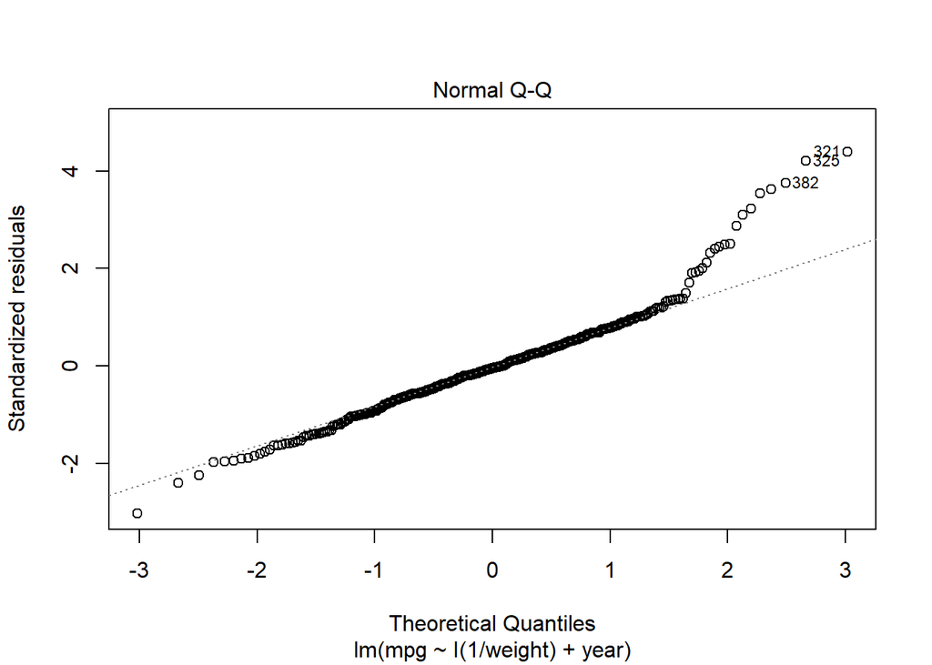

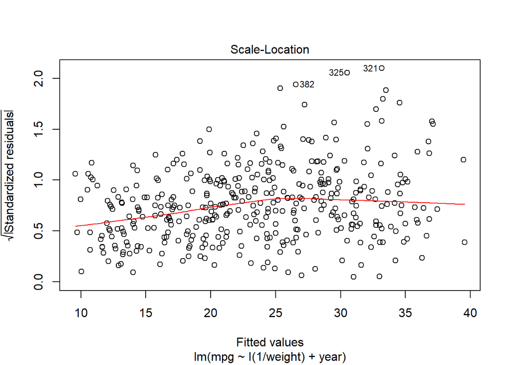

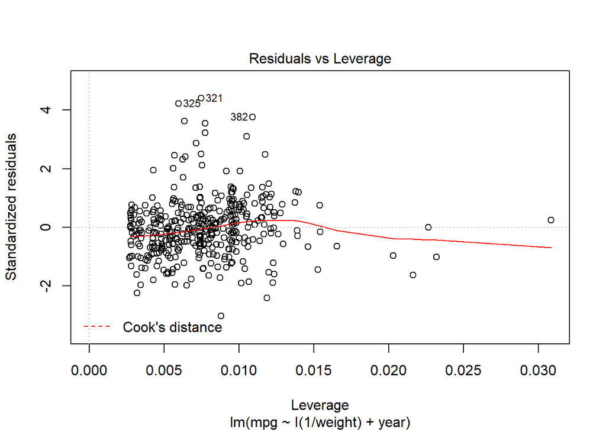

```r
plot(lm.fit.Auto.1_wy)
```

Se ha mejorado el escenario anterior en cuanto a los chequeos de validez de las hipótesis del modelo de regresión lineal. Se contemplan mejoras aplicando otras transformaciones a las variables.